# P3 - Behavioral cloning

[figure not shown]

[figure not shown]

[figure not shown]

[figure not shown]

[figure not shown]

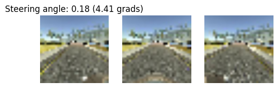

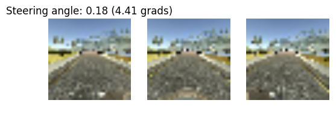

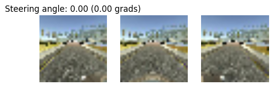

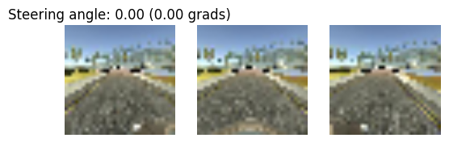

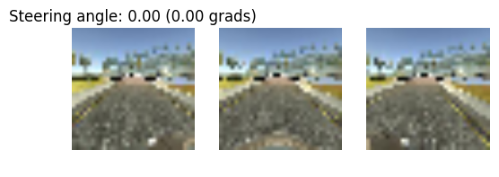

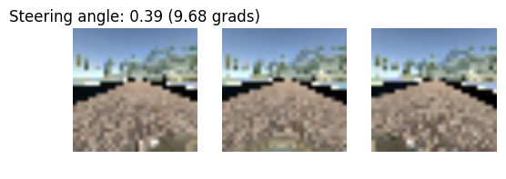

[figure not shown]

[3 more figures not shown]

```python
##
# Plot some images to visualize the data with a new scale
#

for ds in [dataset[below], dataset[zero], dataset[above]]:
    for i in range(n_plot):
            fig1 = plt.subplot(131)
            fig1.set_title('Steering angle: {:.2f} ({:.2f} grads)'.format(ds.iloc[i].steering_angle, ds.iloc[i].steering_angle*25))
            fig1.set_axis_off()
            image = cv2.resize(mpimg.imread(str.strip(ds.iloc[i].left_image)), lenet_shape)
            fig1.imshow(image)

            fig2 = plt.subplot(132)
            fig2.set_axis_off()
            image = cv2.resize(mpimg.imread(ds.iloc[i].center_image), lenet_shape)
            fig2.imshow(image)

            fig3 = plt.subplot(133)
            fig3.set_axis_off()
            image = cv2.resize(mpimg.imread(str.strip(ds.iloc[i].right_image)), lenet_shape)
            fig3.imshow(image)

            plt.show()
```

The final architecture is LeNet. Here we'll see the summary of the network.

Two dropout layers were added to avoid overfitting, one after the flattened layer and one after the first hidden layer.

ELU activation was used because it was proved by Comma.ai autopilot[1] and it showed a better performance than ReLu [2]

This architecture showed very good results with low data and very low processing power requeriments. Actually it was trained with a CPU computer in less than 15 minutes.

[1] https://github.com/commaai/research/blob/master/train_steering_model.py

[2] https://arxiv.org/abs/1511.07289

____________________________________________________________________________________________________ Layer (type) Output Shape Param # Connected to ==================================================================================================== image_normalization (Lambda) (None, 32, 32, 1) 0 lambda_input_1[0][0] ____________________________________________________________________________________________________ convolution_1 (Convolution2D) (None, 28, 28, 6) 156 image_normalization[0][0] ____________________________________________________________________________________________________ elu_1 (ELU) (None, 28, 28, 6) 0 convolution_1[0][0] ____________________________________________________________________________________________________ maxpooling2d_1 (MaxPooling2D) (None, 14, 14, 6) 0 elu_1[0][0] ____________________________________________________________________________________________________ convolution_2 (Convolution2D) (None, 10, 10, 16) 2416 maxpooling2d_1[0][0] ____________________________________________________________________________________________________ elu_2 (ELU) (None, 10, 10, 16) 0 convolution_2[0][0] ____________________________________________________________________________________________________ maxpooling2d_2 (MaxPooling2D) (None, 5, 5, 16) 0 elu_2[0][0] ____________________________________________________________________________________________________ flatten_1 (Flatten) (None, 400) 0 maxpooling2d_2[0][0] ____________________________________________________________________________________________________ dropout_1 (Dropout) (None, 400) 0 flatten_1[0][0] ____________________________________________________________________________________________________ hidden1 (Dense) (None, 120) 48120 dropout_1[0][0] ____________________________________________________________________________________________________ elu_3 (ELU) (None, 120) 0 hidden1[0][0] ____________________________________________________________________________________________________ dropout_2 (Dropout) (None, 120) 0 elu_3[0][0] ____________________________________________________________________________________________________ hidden2 (Dense) (None, 84) 10164 dropout_2[0][0] ____________________________________________________________________________________________________ elu_4 (ELU) (None, 84) 0 hidden2[0][0] ____________________________________________________________________________________________________ hidden3 (Dense) (None, 10) 850 elu_4[0][0] ____________________________________________________________________________________________________ elu_5 (ELU) (None, 10) 0 hidden3[0][0] ____________________________________________________________________________________________________ steering_angle (Dense) (None, 1) 11 elu_5[0][0] ==================================================================================================== Total params: 61,717 Trainable params: 61,717 Non-trainable params: 0 ____________________________________________________________________________________________________

## Discussion

This was the most challenging project in the whole nano degree. Sometimes, I've found that results were counter intuitive and there was not a clear way to improve your model besides trying it on the simulator.

Even though a good advance in finishing the track 1 was made, this architecture needs more work to finish track 2 and to be more robust.

The lesson learned are:

- Nvidia and Comma.ai architectures need lots of data
- **very good** data is key for success
- Data balance is as important as the quality of the data: very different results were found depending on the proportion of ~0 angles included in the dataset. Final results included ~5% of 0 angle
- Even small and simple architecture (as LeNet) are good start for complex problems

LeNet was chosen after having tried Nvidia, Comma.ai and custom architectures with poor results. Without much hope, LeNet performed surprisingly well.

Only Udacity data was used on this model given that its quality was by far better than what I could get.

Things that added randomness to the project:

Hardware: this project was quiet hardware dependent. I even tried known working models (tested on GPU) that didn't worked on my setup Data collection: the simulator and the data provided by it sometimes seemed strange, like a straight road and a very high angle (maybe were the images posterior of a big turn)

## Instructions

```
python drive.py model.hdf5
```

Driving could be run as:

```
python drive.py model.hdf5
```

Simulator settings: Screen resolution '640x480', Graphics Quality 'Fastest'

How to convert .hdf5 to .json and .h5

```
python hdf5_to_jsonh5.py model.hdf5
```

A recording names **track1.mp4** is provided to see the car driving on my own setup